# Assessing Market Concentration in US Banking

The file "bank-data.csv" contains data on the number of commercial banking institutions, branches, and offices in the United States at the end of each year between 1934 to 2019. (This data is maintained by the Federal Deposit Insurance Corporation (FDIC) and can be downloaded from https://banks.data.fdic.gov/. The FDIC has a lot of interesting banking data. You are encouraged to browse around their website to see what's there.)

## Load and Clean Data

```python
import pandas as pd
banking_data = pd.read_csv('C:/Users/rudyd/Downloads/bank-data.csv', header = 6, parse_dates = ['YEAR'], index_col = 'YEAR')
banking_data.columns = banking_data.columns.str.lower()
banking_data.rename(columns={'institutions':'banks'}, inplace=True)
banking_data = banking_data.drop(columns='branches')
banking_data
```

| YEAR | id | new_char | offices | stname | banks |
| --- | --- | --- | --- | --- | --- |
| 2019-01-01 | CB_2019_99 | 13.0 | 80984 | United States | 4511 |
| 2018-01-01 | CB_2018_99 | 7.0 | 81480 | United States | 4708 |
| 2017-01-01 | CB_2017_99 | 5.0 | 82730 | United States | 4909 |
| 2016-01-01 | CB_2016_99 | 0.0 | 84209 | United States | 5102 |
| 2015-01-01 | CB_2015_99 | 1.0 | 85867 | United States | 5330 |
| ... | ... | ... | ... | ... | ... |
| 1938-01-01 | CB_1938_99 | NaN | 17071 | United States | 13660 |
| 1937-01-01 | CB_1937_99 | NaN | 17176 | United States | 13796 |
| 1936-01-01 | CB_1936_99 | NaN | 17232 | United States | 13972 |
| 1935-01-01 | CB_1935_99 | NaN | 17237 | United States | 14125 |
| 1934-01-01 | CB_1934_99 | NaN | 14146 | United States | 0 |

86 rows × 5 columns

```python
banking_data['offices_per_bank'] = banking_data['offices']/banking_data['banks'].rolling(1).mean().fillna(0)
banking_data
```

| YEAR | id | new_char | offices | stname | banks | offices_per_bank |
| --- | --- | --- | --- | --- | --- | --- |
| 2019-01-01 | CB_2019_99 | 13.0 | 80984 | United States | 4511 | 17.952560 |
| 2018-01-01 | CB_2018_99 | 7.0 | 81480 | United States | 4708 | 17.306712 |
| 2017-01-01 | CB_2017_99 | 5.0 | 82730 | United States | 4909 | 16.852719 |
| 2016-01-01 | CB_2016_99 | 0.0 | 84209 | United States | 5102 | 16.505096 |
| 2015-01-01 | CB_2015_99 | 1.0 | 85867 | United States | 5330 | 16.110131 |
| ... | ... | ... | ... | ... | ... | ... |
| 1938-01-01 | CB_1938_99 | NaN | 17071 | United States | 13660 | 1.249707 |
| 1937-01-01 | CB_1937_99 | NaN | 17176 | United States | 13796 | 1.244999 |
| 1936-01-01 | CB_1936_99 | NaN | 17232 | United States | 13972 | 1.233324 |
| 1935-01-01 | CB_1935_99 | NaN | 17237 | United States | 14125 | 1.220319 |
| 1934-01-01 | CB_1934_99 | NaN | 14146 | United States | 0 | inf |

86 rows × 6 columns

## Visualize the Data

```python
import matplotlib.pyplot as plt
from matplotlib.dates import date2num
%matplotlib inline
```

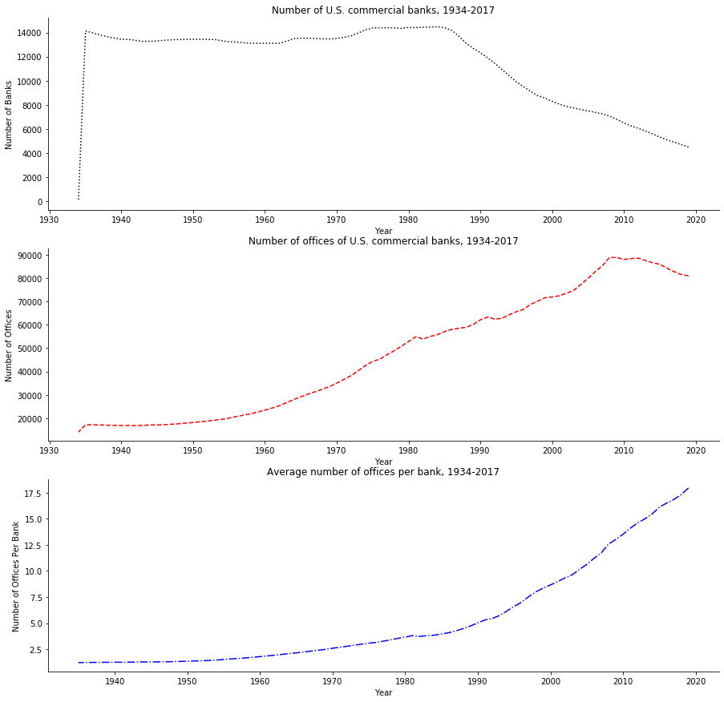

```python
fig, ax = plt.subplots(3, figsize=(15,15))
ax[0].plot(banking_data.index, banking_data['banks'], linestyle = 'dotted',color='black', label = 'Number of Banks')
ax[0].set_xlabel('Year')
ax[0].set_ylabel('Number of Banks')
ax[0].set_title('Number of U.S. commercial banks, 1934-2017')
ax[0].spines['right'].set_visible(False)
ax[0].spines['top'].set_visible(False)

ax[1].plot(banking_data.index, banking_data['offices'], linestyle = 'dashed',color='red', label = 'Number of Offices')
ax[1].set_xlabel('Year')
ax[1].set_ylabel('Number of Offices')
ax[1].set_title('Number of offices of U.S. commercial banks, 1934-2017')
ax[1].spines['right'].set_visible(False)
ax[1].spines['top'].set_visible(False)

ax[2].plot(banking_data.index, banking_data['offices_per_bank'], linestyle = 'dashdot',color='blue', label = 'Number of offices per bank')
ax[2].set_xlabel('Year')
ax[2].set_ylabel('Number of Offices Per Bank')
ax[2].set_title('Average number of offices per bank, 1934-2017')
ax[2].spines['right'].set_visible(False)
ax[2].spines['top'].set_visible(False)
```

## Incorporate External Research

```
Text(2010-07-21 00:00:00, 7.5, 'Dodd-Frank Act Signed')
```

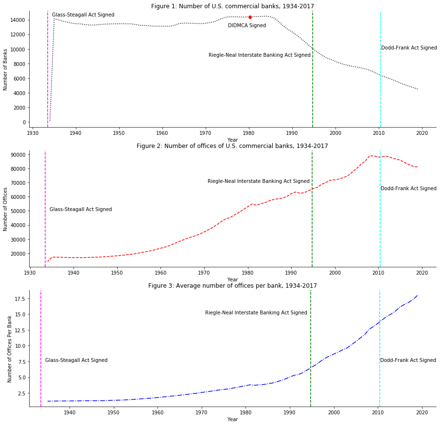

```python
fig, ax = plt.subplots(3, figsize=(15,15))
ax[0].plot(banking_data.index, banking_data['banks'], linestyle = 'dotted',color='black', label = 'Number of Banks')
ax[0].set_xlabel('Year')
ax[0].set_ylabel('Number of Banks')
ax[0].set_title('Figure 1: Number of U.S. commercial banks, 1934-2017')
ax[0].spines['right'].set_visible(False)
ax[0].spines['top'].set_visible(False)
ax[0].axvline(pd.to_datetime('1994-09-29'), color="green", linestyle="--")
ax[0].text(pd.to_datetime('1970-09-29'),9000,'Riegle-Neal Interstate Banking Act Signed')
ax[0].axvline(pd.to_datetime('1933-06-16'), color="magenta", linestyle="--")
ax[0].text(pd.to_datetime('1934-06-16'),14500,'Glass-Steagall Act Signed')
ax[0].axvline(pd.to_datetime('2010-06-21'), color="cyan", linestyle="--")
ax[0].text(pd.to_datetime('2010-07-21'),10000,'Dodd-Frank Act Signed')
ax[0].plot(pd.to_datetime('1980-03-31'),14350,'ro')
ax[0].text(pd.to_datetime('1975-03-31'),13000,'DIDMCA Signed')

ax[1].plot(banking_data.index, banking_data['offices'], linestyle = 'dashed',color='red', label = 'Number of Offices')
ax[1].set_xlabel('Year')
ax[1].set_ylabel('Number of Offices')
ax[1].set_title('Figure 2: Number of offices of U.S. commercial banks, 1934-2017')
ax[1].spines['right'].set_visible(False)
ax[1].spines['top'].set_visible(False)
ax[1].axvline(pd.to_datetime('1994-09-29'), color="green", linestyle="--")
ax[1].text(pd.to_datetime('1970-09-29'),70000,'Riegle-Neal Interstate Banking Act Signed')
ax[1].axvline(pd.to_datetime('1933-06-16'), color="magenta", linestyle="--")
ax[1].text(pd.to_datetime('1934-06-16'),50000,'Glass-Steagall Act Signed')
ax[1].axvline(pd.to_datetime('2010-06-21'), color="cyan", linestyle="--")
ax[1].text(pd.to_datetime('2010-07-21'),65000,'Dodd-Frank Act Signed')

ax[2].plot(banking_data.index, banking_data['offices_per_bank'], linestyle = 'dashdot',color='blue', label = 'Number of offices per bank')
ax[2].set_xlabel('Year')
ax[2].set_ylabel('Number of Offices Per Bank')
ax[2].set_title('Figure 3: Average number of offices per bank, 1934-2017')
ax[2].spines['right'].set_visible(False)
ax[2].spines['top'].set_visible(False)
ax[2].axvline(pd.to_datetime('1994-09-29'), color="green", linestyle="--")
ax[2].text(pd.to_datetime('1970-09-29'),15.0,'Riegle-Neal Interstate Banking Act Signed')
ax[2].axvline(pd.to_datetime('1933-06-16'), color="magenta", linestyle="--")
ax[2].text(pd.to_datetime('1934-06-16'),7.5,'Glass-Steagall Act Signed')
ax[2].axvline(pd.to_datetime('2010-06-21'), color="cyan", linestyle="--")
ax[2].text(pd.to_datetime('2010-07-21'),7.5,'Dodd-Frank Act Signed')
```

Since the Glass-Steagall Act, the total number of U.S commercial banks remained relatively the same (with banks steadily increasing the number of offices they had -- refer to Figure 2) until the 1980s when the number started to decline. The banks had started losing market share to other financial institutions, and so in 1980 Congress passed the Depository Institutions Deregulation and Monetary Control Act (DIDMCA). This act deregulated the financial insitutions that accept deposits while strengthening the Federal Reserve's control over Monetary policy. This act accelerated the move towards consolidation and conglomeration of the commercial banks. This can be seen in Figure 1: the decline in the number of commercial banks begins shortly after the passage of the DIDMCA.

In addition to the DIDMCA, in 1994 Congress passed the Riegle-Neal Interstate Banking Act. This act allowed banks to cross state line and establish offices under a national uniform standard. THE DIDMCA led to the decrease in commercial banking companies and the Riegle-Neal Act allowed the remaining commercial banking companies to increase the number of offices they had, and thus the average number of offices per bank started increasing at a much faster rate after the passage of the Riegel-Neal Act compared to before -- refer to Figure 3.

Finally, referring to Figure 2, there is a clear decrease in the number of offices of commercial banks around 2008. This decrease can be attributed to the Great Recession along with the passage of the Dodd-Frank Act. As a result of the Great Recession, a number of large banks had to close numerous offices around the country, and the passage of the Dodd-Frank Act further regulated the industry and forced the big banks to offload a number of the smaller offices/banks they owned around the country.

# IMDB Data

In this exercise we will evaluate the career trajectories of Hollywood directors and actors.

## Collect and Clean Data

```python
import requests
import numpy as np
import pandas as pd

from requests import get
from bs4 import BeautifulSoup
```

```python
#----------------------------------------------
# Step One - Collect Data
#----------------------------------------------

from time import sleep
from random import randint

titles = []
years = []
time = []
imdb_ratings = []
us_gross = []
directors = []
actors = []

pages = np.arange(1, 1001, 50) # start at 1, stop at 1001 (actually, stop at 1000 b/c 1001 not included), and go in increments of 50

# Tracker
itr = 0
threshold = 10.0

for numpage in pages:    # Loop across pages

    sleep(randint(2,10)) # Pause for between 2 and 10 seconds

    url = "https://www.imdb.com/search/title/?groups=top_1000&start=" + str(numpage) + "&ref_=adv_nxt"

    # Using Beautiful Soup
    page = requests.get(url, headers=headers)
    content = BeautifulSoup(page.text, 'html.parser')

    movie_div = content.find_all('div', class_='lister-item mode-advanced')

    for container in movie_div:

        name = container.h3.a.text
        titles.append(name)

        year = container.h3.find('span', class_='lister-item-year').text
        years.append(year)

        runtime = container.p.find('span', class_='runtime') if container.p.find('span', class_='runtime') else 'N/A'
        time.append(runtime)

        imdb = float(container.strong.text)
        imdb_ratings.append(imdb)

        nv = container.find_all('span', attrs={'name': 'nv'})

        gross = nv[1].text if len(nv) > 1 else 'N/A'
        us_gross.append(gross)

        director = container.find('p', class_="").a.text
        directors.append(director)

        container.find_all('a')[14:18]

        actor = container.find_all('a')[14:18]
        actors.append(actor)

    # Print Status
    itr += 1
    if (100*itr/len(pages)>=threshold):
        print('Pecent Complete: ', threshold, '%')
        threshold += 10.0

#----------------------------------------------
# Step Two - Convert to DataFrame
#----------------------------------------------
movies = pd.DataFrame({
'movie': titles,
'year': years,
'imdb': imdb_ratings,
'us_grossMillions': us_gross,
'timeMin': time,
'directors': directors,
'actors': actors
})
```

```
Pecent Complete:  10.0 %
Pecent Complete:  20.0 %
Pecent Complete:  30.0 %
Pecent Complete:  40.0 %
Pecent Complete:  50.0 %
Pecent Complete:  60.0 %
Pecent Complete:  70.0 %
Pecent Complete:  80.0 %
Pecent Complete:  90.0 %
Pecent Complete:  100.0 %
```

1. Clean the raw scraped data using "regular expressions" via `re`.

```python
movies.loc[:, 'year'] = movies['year'].str[-5:-1].astype(int)

movies['timeMin'] = movies['timeMin'].astype(str)
movies['timeMin'] = movies['timeMin'].str.extract('(\d+)').astype(int)

movies['us_grossMillions'] = movies['us_grossMillions'].map(lambda x: x.lstrip('$').rstrip('M'))
movies['us_grossMillions'] = pd.to_numeric(movies['us_grossMillions'], errors='coerce')

# Sort in descending value by imdb score
movies.sort_values(by=['imdb'],ascending=False,inplace=True)

# to see your dataframe
print(movies.head())

# to see the datatypes of your columns
print('\n')
print(movies.dtypes)

# to see where you're missing data and how much data is missing
print('\n')
print(movies.isnull().sum())

# save scraped data to a CSV file in the cwd
movies.to_csv('IMDB_raw.csv')
```

```
                        movie  year  imdb  us_grossMillions  timeMin  \
6    The Shawshank Redemption  1994   9.3             28.34      142
8               The Godfather  1972   9.2            134.97      175
5             The Dark Knight  2008   9.0            534.86      152
108              12 Angry Men  1957   9.0              4.36       96
125    The Godfather: Part II  1974   9.0             57.30      202

                directors                                             actors
6          Frank Darabont  [[Tim Robbins], [Morgan Freeman], [Bob Gunton]...
8    Francis Ford Coppola  [[Marlon Brando], [Al Pacino], [James Caan], [...
5       Christopher Nolan  [[Christian Bale], [Heath Ledger], [Aaron Eckh...
108          Sidney Lumet  [[Henry Fonda], [Lee J. Cobb], [Martin Balsam]...
125  Francis Ford Coppola  [[Al Pacino], [Robert De Niro], [Robert Duvall...


movie                object
year                  int32
imdb                float64
us_grossMillions    float64
timeMin               int32
directors            object
actors               object
dtype: object


movie                 0
year                  0
imdb                  0
us_grossMillions    168
timeMin               0
directors             0
actors                0
dtype: int64
```

```python
import pandas as pd
pd.core.common.is_list_like = pd.api.types.is_list_like
from pandas_datareader import data, wb
import matplotlib.pyplot as plt
import datetime as dt
import re
import numpy as np
```

```python
start = dt.datetime(1920, 1, 1)
fred = data.DataReader('CPILFESL', 'fred', start)
fred.columns = ['CPI']
fred[fred.index=='1983-08-01']
```

| DATE | CPI |
| --- | --- |
| 1983-08-01 | 100.1 |

```python
imdb = pd.read_csv('IMDB_raw.csv', parse_dates = ['year']).dropna(subset=['us_grossMillions'])
imdb['actors'] = imdb['actors'].replace(to_replace='<[^>]+>',value='',regex=True)
```

```python
imdb_cpi = pd.merge(left=imdb,right=fred,how='left',left_on='year',right_on=fred.index)
```

```python
imdb_cpi = imdb_cpi.set_index('year')
```

```python
imdb_cpi['real_us_grossMillions_(Index 1982-1984=100)'] = imdb_cpi['us_grossMillions']/(imdb_cpi['CPI']/100)
imdb_cpi.head()
```

| year | Unnamed: 0 | movie | imdb | us_grossMillions | timeMin | directors | actors | CPI | real_us_grossMillions_(Index 1982-1984=100) |
| --- | --- | --- | --- | --- | --- | --- | --- | --- | --- |
| 1994-01-01 | 6 | The Shawshank Redemption | 9.3 | 28.34 | 142 | Frank Darabont | [Tim Robbins, Morgan Freeman, Bob Gunton, Will... | 154.500 | 18.343042 |
| 1972-01-01 | 8 | The Godfather | 9.2 | 134.97 | 175 | Francis Ford Coppola | [Marlon Brando, Al Pacino, James Caan, Diane K... | 43.500 | 310.275862 |
| 2008-01-01 | 5 | The Dark Knight | 9.0 | 534.86 | 152 | Christopher Nolan | [Christian Bale, Heath Ledger, Aaron Eckhart, ... | 213.771 | 250.202319 |
| 1957-01-01 | 108 | 12 Angry Men | 9.0 | 4.36 | 96 | Sidney Lumet | [Henry Fonda, Lee J. Cobb, Martin Balsam, John... | 28.500 | 15.298246 |
| 1974-01-01 | 125 | The Godfather: Part II | 9.0 | 57.30 | 202 | Francis Ford Coppola | [Al Pacino, Robert De Niro, Robert Duvall, Dia... | 46.900 | 122.174840 |

## Part (b): Analyze Data and Present Results [20 points]

1. Identify the director, actor, and actress with the highest total box office revenues in the IMDB database.

```python
max_director = pd.DataFrame(imdb_cpi.groupby('directors').sum()['real_us_grossMillions_(Index 1982-1984=100)'])
max_director.idxmax()
```

```
real_us_grossMillions_(Index 1982-1984=100)    Steven Spielberg
dtype: object
```

```python
imdb_spielberg = imdb_cpi[imdb_cpi['directors'] == 'Steven Spielberg'].sort_index()
```

```python
new=imdb_cpi.assign(actors=imdb_cpi.actors.str.split(",")).explode('actors')
new['actors']=[s.replace('[', '') for s in new['actors']]
new['actors']=[s.replace(']', '') for s in new['actors']]
new['actors']=new['actors'].map(lambda x: x.lstrip(' '))
max_actors = new.groupby(new['actors']).aggregate({'real_us_grossMillions_(Index 1982-1984=100)':'sum'})
np.where(max_actors['real_us_grossMillions_(Index 1982-1984=100)'] == max(max_actors['real_us_grossMillions_(Index 1982-1984=100)']))
max_actors.iloc[699]
max_actors.sort_values(by = 'real_us_grossMillions_(Index 1982-1984=100)')
#Carrie Fisher and Harrison Ford are the highest grossing actress and actor, respectively
```

| actors | real_us_grossMillions_(Index 1982-1984=100) |
| --- | --- |
| Ray Milland | 0.000000 |
| George O'Brien | 0.000000 |
| John Ridgely | 0.000000 |
| Masayuki Mori | 0.000000 |
| Chico Marx | 0.000000 |
| ... | ... |
| Mark Hamill | 1239.703430 |
| Robert Downey Jr. | 1296.898634 |
| Carrie Fisher | 1313.078925 |
| Tom Hanks | 1543.256267 |
| Harrison Ford | 1880.642041 |

2284 rows × 1 columns

```python
imdb_ford = new[new['actors'] == 'Harrison Ford'].sort_index()
imdb_fisher = new[new['actors'] == 'Carrie Fisher'].sort_index()
```

1. Plot the history of total revenues for each of these three in the same figure. Make sure the plot is clean and professional-looking (e.g., axis labels are clear, no spines, axis labels include thousands separator if needed, text is easilly readable, the x-axis should not be cramped, the reader should not have to tilt their head to read the year on the x-axis). Your plots may use `matplotlib` or `plotly`.

[figure not shown]

```python
import matplotlib.pyplot as plt
%matplotlib inline
fig, ax = plt.subplots(figsize=(12,12))
ax.plot(imdb_spielberg.index, imdb_spielberg['real_us_grossMillions_(Index 1982-1984=100)'], color='red',
        label = 'Steven Spielberg (Highest Earning Director)')
ax.plot(imdb_ford.index, imdb_ford['real_us_grossMillions_(Index 1982-1984=100)'], color='blue',
       label = 'Harrison Ford (Highest Earning Actor)')
ax.plot(imdb_fisher.index, imdb_fisher['real_us_grossMillions_(Index 1982-1984=100)'], color='green',
       label = 'Carrie Fisher (Highest Earning Actress)')
ax.set_xlabel('Year')
ax.set_ylabel('Millions of Dollars (Real Dollars 1982-1984 Index)')
ax.set_title('History of Total Movie Revenues (from IMDB Top 1000 Movies)')
ax.spines['right'].set_visible(False)
ax.spines['top'].set_visible(False)
ax.legend(frameon=False)
```

1. Comment on the trends you observe in the figure

Given the line plots, the easiest observation to make is that Spielberg, Ford, and the late Carrie Fisher were at their prime in terms of marketability and the ability to bring in revenue in the time period between 1975 and 1985. Ever since then, all three declined drastically in being able to bring in revenue for their movies. They're still the highest earning director, actor, and actress in this time period though, so they were still bringing in high revenues compared to other actors; they just weren't bringing in the same level of revenue compared to their younger selves.

1. [Optional] Plot revenue share by genre since 1980 and comment on trends. *Ten bonus points*.